# Week 2 - Homework

STAT 420, Summer 2017, Megan Masanz, netId: mjneuman

**Note** to properly knit this Rmd file, the `MASS` andi `knitr` libraries must be installed as shown below, but this **not** evaluated in this solution to ensure speed of build for solution.

```r
install.packages("MASS")
install.packages("knitr")
```

## Exercise 1 (Using `lm`)

This exercise used the `cats` dataset from the `MASS` package.

```r
library(MASS)
```

**(a)** Below is a simple linear model in `R` that helps to understand the size of cat’s heart based on the body weight of a cat outputting the result of calling `summary()` on `cat_model`

```r
cat_model = lm(Hwt ~ Bwt, data = cats)
summary(cat_model)
```

```
##
## Call:
## lm(formula = Hwt ~ Bwt, data = cats)
##
## Residuals:
##     Min      1Q  Median      3Q     Max
## -3.5694 -0.9634 -0.0921  1.0426  5.1238
##
## Coefficients:
##             Estimate Std. Error t value Pr(>|t|)
## (Intercept)  -0.3567     0.6923  -0.515    0.607
## Bwt           4.0341     0.2503  16.119   <2e-16 ***
## ---
## Signif. codes:  0 '***' 0.001 '**' 0.01 '*' 0.05 '.' 0.1 ' ' 1
##
## Residual standard error: 1.452 on 142 degrees of freedom
## Multiple R-squared:  0.6466, Adjusted R-squared:  0.6441
## F-statistic: 259.8 on 1 and 142 DF,  p-value: < 2.2e-16
```

**(b)** Below is the ouput of the estimated regression coefficients.

```r
coef(cat_model)
```

```
## (Intercept)         Bwt
##  -0.3566624   4.0340627
```

The intercept parameter $\beta_0$ is a model parameter that tells us the mean value of a cat’s heart weight in grams when a cat weights 0 kg.

The estimated mean value $\hat{\beta_1}$ = 4.0340627 tells us for an increase of one kg in body weight, the estimated mean heart weight in grams increase by 4.0340627.

**(c)** Below is using the model created to predict the heart weight in grams of a cat that weights **3.3** kg.

Given 3.3 kg is a weight found within the dataset and it is within the range of weights used to calculate the SLR model, I can feel confident in this prediction.

```r
predict(cat_model, newdata = data.frame(Bwt = 3.3))
```

```
##        1
## 12.95574
```

```r
3.3 %in% unique(cats$Bwt)
```

```
## [1] TRUE
```

```r
min(cats$Bwt) < 3.3 & 3.3 < max(cats$Bwt)
```

```
## [1] TRUE
```

**(d)** Below is using the model to predict the heart weight (grams) of a cat that weights **1.5** kg. Given **1.5** kg is not in the initial data set, and is not in the range of values used to create the model, this is considered exterpolation and I do not have confidence in this prediction.

```r
predict(cat_model, newdata = data.frame(Bwt = 1.5))
```

```
##        1
## 5.694432
```

```r
1.5 %in% unique(cats$Bwt)
```

```
## [1] FALSE
```

```r
min(cats$Bwt) < 1.5 & 1.5 < max(cats$Bwt)
```

```
## [1] FALSE
```

**(e)** Below is a scatterplot of the data and the fitted regression line.

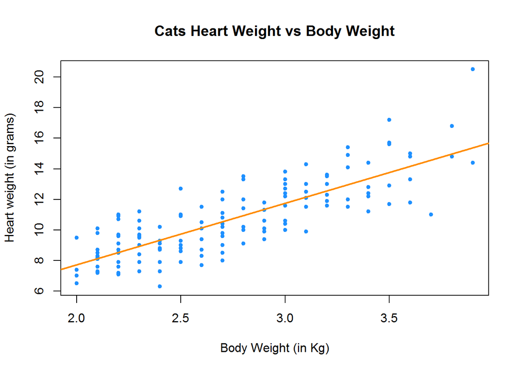

```r
plot(Hwt ~ Bwt, data = cats,
     xlab = "Body Weight (in Kg)",
     ylab = "Heart weight (in grams)",
     main = "Cats Heart Weight vs Body Weight",
     pch  = 20,
     cex  = 1,
     col  = "dodgerblue")

abline(cat_model$coefficients["(Intercept)"], cat_model$coefficients["Bwt"], col = "darkorange", lwd = 2)
```

**(f)** Below is the value of $R^2$ for the model.

```r
summary(cat_model)$r.squared
```

```
## [1] 0.6466209
```

## Exercise 2 (Writing Functions)

This exercise is a continuation of Exercise 1.

**(a)** Below is a function called `get_sd_est` that calculates an estimate of $\sigma$ in two ways:

- $s_e$ if `mle` is set to `FALSE`.
- $\hat{\sigma}$ if `mle` is set to `TRUE`.

With input parameters:

- `model_resid` - A vector of residual values from a fitted model.
- `mle` - A logical (`TRUE` / `FALSE`) variable which defaults to `FALSE`.

```r
get_sd_est = function(model_resid, mle = FALSE) {
  if (mle == FALSE) {
  sqrt(sum(model_resid ^ 2) / (length(model_resid) - 2))
  } else{
  sqrt((sum(model_resid ^ 2) / length(model_resid)))
  }
}
```

**(b)** Below is running the function `get_sd_est` on the residuals from the model in Exercise 1 with `mle` set to `FALSE`.

```r
get_sd_est(cat_model$residuals, FALSE)
```

```
## [1] 1.452373
```

**(c)** Below is running the function `get_sd_est` on the residuals from the model in Exercise 1 with `mle` set to `TRUE`

```r
get_sd_est(cat_model$residuals, TRUE)
```

```
## [1] 1.442252
```

**(d)** Below is the output `summary(cat_model)$sigma`

```r
summary(cat_model)$sigma
```

```
## [1] 1.452373
```

which matches the calculation of sigma when the input parameter is `FALSE` indicating it matches the $s_e$ calculation.

```r
summary(cat_model)$sigma == get_sd_est(cat_model$residuals, FALSE)
```

```
## [1] TRUE
```

## Exercise 3 (Simulating SLR)

Consider the model

$$Y_i = -4 + 2 x_i + \epsilon_i$$

with

$$\epsilon_i \sim N(\mu = 0, \sigma^2 = 6.25)$$

where $\beta_0 = -4$ and $\beta_1 = 2$.

This exercise relies heavily on generating random observations. To make this reproducible we will set a seed for the randomization. The following code to makes `birthday` and stores my birthday of August 3, 1981 in the format: `yyyymmdd`.

**(a)** Below shows using `R` to simulate `n = 50` observations from the above model. The remainder of the exercise uses the following “known” values of $x$ Using the `sim_slr` function in the text, a data frame is stored in `sim_data`. *Note the the function shown below calls $y$ response and $x$ predictor.*

```r
birthday = 19810803
set.seed(birthday)
x = runif(n = 50, 0, 10)

beta_0 = -4
beta_1 = 2
sigma = sqrt(6.25)

sim_slr = function(x, beta_0, beta_1, sigma) {
  n = length(x)
  epsilon = rnorm(n, mean = 0, sd = sigma)
  y = beta_0 + beta_1 * x + epsilon
  data.frame(predictor = x, response = y)
}

sim_data = sim_slr(x, beta_0, beta_1, sigma)
```

**(b)** Below shows fitting a model to the simulated data and then reporting the estimated coefficients.

```r
sim_fit = lm(sim_data$response ~ sim_data$predictor)
coef(sim_fit)
```

```
##        (Intercept) sim_data$predictor
##          -4.767234           2.015571
```

These values were what I had expected.

Given $\beta_1$ = 2 and the calculated mean of that value $\hat{\beta_1}$ was 2.0155705 is pretty close.

Given $\beta_0$ = -4 and the range of values for $x_i$ was from 0.2796879 to 9.9107913, I would expect to see the value have a higher error so a value of -4.7672336 is to be expected given the range and the small sample set shown below.

```r
range(sim_data$predictor)
```

```
## [1] 0.2796879 9.9107913
```

**(c)** Below is a plot of the simulated data in part **(a)** as grey dots. The regression line part from **(b)** is in orange and the line of the true model is the blue dotted line.

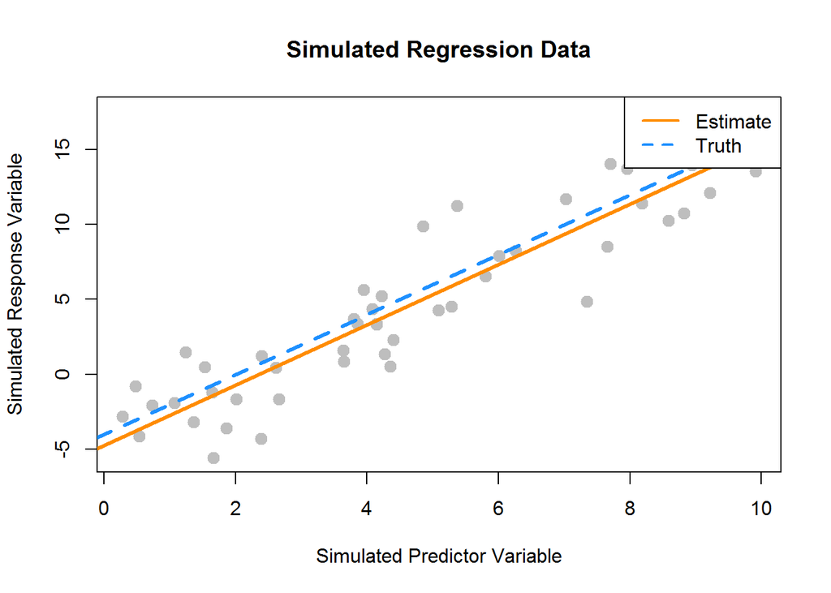

```r
#simulated data
plot(response ~ predictor, data = sim_data,
     xlab = "Simulated Predictor Variable",
     ylab = "Simulated Response Variable",
     main = "Simulated Regression Data",
     pch  = 20,
     cex  = 2,
     col  = "grey")
abline(sim_fit, lwd = 3, lty = 1, col = "darkorange")
abline(beta_0, beta_1, lwd = 3, lty = 2, col = "dodgerblue")
legend("topright", c("Estimate", "Truth"), lty = c(1, 2), lwd = 2,
       col = c("darkorange", "dodgerblue"))
```

**(d)** Using a for loop in `R` below you will find the process of simulating `n=50` observations from the above model $2000$ times. For the given model, the $x_i$ values remain constant and new response data is calculated. Each time new response data $y_i$ is calculated, a SLR model is fit to the data and the $\hat{\beta_1}$ value is stored to a variable that is called `beta_hat_1` which has been initialized.

- After simulating the data, the `lm()` function is used to to fit a regression.
- The `coef()` function and `[]` are used to extract the correct estimated coefficient.
- `beta_hat_1[i]` is used to store in elements of `beta_hat_1`.

```r
sim_beta_1_hat = function(x, beta_0, beta_1, sigma) {
    beta_hat_1 = rep(0, 2000)
    n = length(x)
    for (i in 1:2000){
    epsilon = rnorm(n, mean = 0, sd = sigma)
    y = beta_0 + beta_1 * x + epsilon
    sim_data = data.frame(predictor = x, response = y)
    sim_model = lm(response ~ predictor, data = sim_data)
    beta_hat_1[i] = coef(sim_model)[2]
  }
  beta_hat_1
}
beta_hat_1 = sim_beta_1_hat(x, beta_0, beta_1, sigma)
```

**(e)** Below is the mean of `beta_hat_1` which looks very much like the true value of $\beta_1$ and would be a very good approximation for $\hat{\beta_1}$

```r
mean(beta_hat_1)
```

```
## [1] 2.000666
```

**(e)** Below is the standard deviation of `beta_hat_1`.

```r
sd(beta_hat_1)
```

```
## [1] 0.1241644
```

**(f)** Below is a histogram of `beta_hat_1`. It appears to follow the shape of a normal distribution. The mean looks to be at approximately 2, as expected.

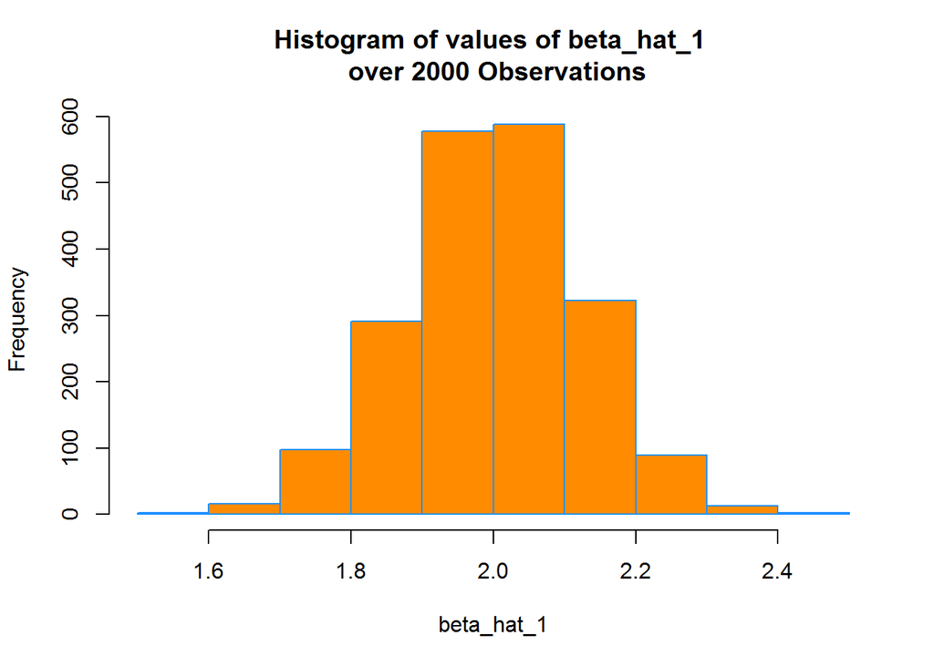

```r
hist(beta_hat_1,
     xlab = "beta_hat_1",
     main = "Histogram of values of beta_hat_1 \n over 2000 Observations",
     col = "darkorange",
     border = "dodgerblue")
```

## Exercise 4 (Be a Skeptic)

Consider the model

$$Y_i = 10 + 0 x_i + \epsilon_i$$

with

$$\epsilon_i \sim N(\mu = 0, \sigma^2 = 1)$$

where $\beta_0 = 10$ and $\beta_1 = 0$.

Below you will see setting a seed value equal to **my** birthday, as was done in the previous exercise for August 03, 1981.

```r
birthday = 19810803
set.seed(birthday)
x = runif(n = 25, 0, 10)
```

**(a)** Use `R` to repeat the process of simulating `n = 25` observations from the above model $1500$ times. For the remainder of this exercise, use the following “known” values of $x$.

Each time fit a SLR model to the data and store the value of $\hat{\beta_1}$ in a variable called `beta_hat_1`. You may use [the `sim_slr` function provided in the text](http://daviddalpiaz.github.io/appliedstats/simple-linear-regression.html#simulating-slr). Hint: Yes $\beta_1 = 0$.

```r
sigma  = 1
beta_0 = 10
beta_1 = 0

sim_beta_hat_1 = function(x, beta_0, beta_1, sigma) {
  beta_hat_1 = rep(0, 1500)
  n = length(x)
  for (i in 1:1500){
    epsilon = rnorm(n, mean = 0, sd = sigma)
    y = beta_0 + beta_1 * x + epsilon
    sim_data = data.frame(predictor = x, response = y)
    sim_model = lm(response ~ predictor, data = sim_data)
    beta_hat_1[i] = coef(sim_model)[2]
  }
  return(beta_hat_1)
}

beta_hat_1 = sim_beta_hat_1(x, beta_0, beta_1, sigma)
```

**(b)** Plot a histogram of `beta_hat_1`. The shape of the histogram follows a normal distribution.

- The mean appears to be at zero or very close to it.
- The shape appears to be symetrical about the zero value of x following a normal distribution.

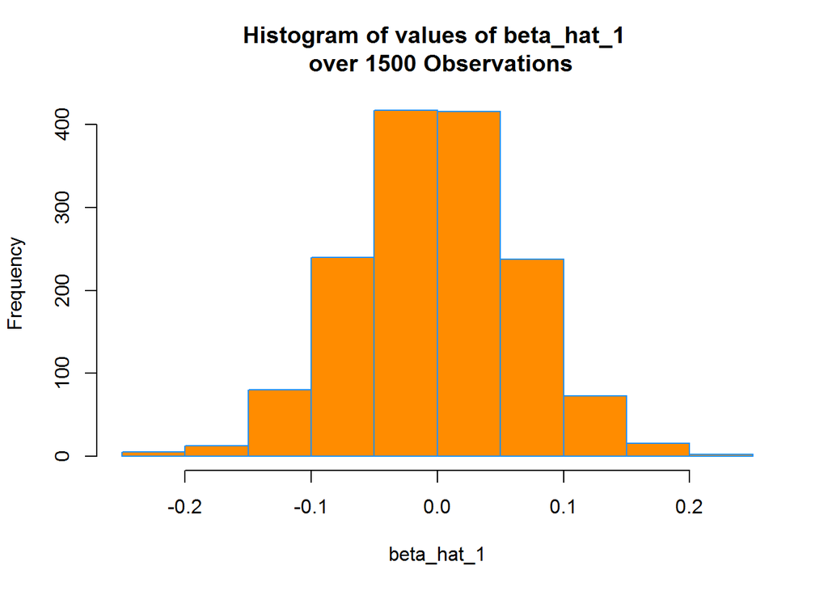

```r
hist(beta_hat_1,
     xlab = "beta_hat_1",
     main = "Histogram of values of beta_hat_1 \n over 1500 Observations",
     col = "darkorange",
     border = "dodgerblue")
```

**(c)** Below is importing data in the skeptic.csv file and fitting a SLR model.

```r
library(readr)
skeptic = read_csv("skeptic.csv")
sim_model_skeptic = lm(response ~ predictor, data = skeptic)
```

Below is the extracted fitted coefficient for $\beta_1$.

```r
coef(sim_model_skeptic)[2]
```

```
## predictor
##  0.154081
```

**(d)** Re-plot the histogram from **(b)**. Now add a vertical red line at the value of $\hat{\beta_1}$ in part **(c)**. To do so, you’ll need to use `abline(v = c, col = "red")` where `c` is your value.

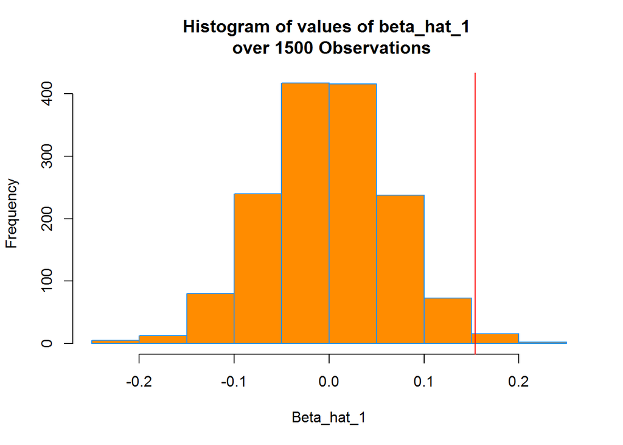

```r
hist(beta_hat_1,
     xlab = "Beta_hat_1",
     main = "Histogram of values of beta_hat_1 \n over 1500 Observations",
     col = "darkorange",
     border = "dodgerblue")
abline(v = sim_model_skeptic$coefficients["predictor"], col = "red")
```

**(e)** Below is the proportion of the `beta_hat_1` values are larger than my $\hat{\beta_1}$ calculated in part of **(c)** 0.154081

```r
length((beta_hat_1[ beta_hat_1 > coef(sim_model_skeptic)[2]]))/length(beta_hat_1)
```

```
## [1] 0.01
```

**(e)** Proportion Multiplied by 2

```r
2* length((beta_hat_1[ beta_hat_1 > coef(sim_model_skeptic)[2]]))/length(beta_hat_1)
```

```
## [1] 0.02
```

**(f)** Based on the histogram and part **(e)**, I do not think the `skeptic.csv` data was generated by this model. I would expect to see the $\hat{\beta_1}$ generated from the skeptic data to be much closer to the mean of the mean of the beta_hat_1 value if it was generated from this model.